# IMRaD report for Karl

Author

Alexandra Stephenson

Published

May 24, 2023

# Introduction

The data set consists of eight gene lines, each with one of two cell lines (wild-type or cell-type 101), one of two treatments (the placebo treatment or activating factor 42), and eleven different concentrations of growth factor (recorded in mg/ml). Thus, for each pair of cell line and treatment, there are two gene lines, each with eleven concentrations of growth factor (from $0$ to $10$). Only one data point is missing, that of concentration $5$ mg/ml for gene line GL-fUg (with cell line wild-type and treatment activating factor 42).

This report investigates the impact of growth factor concentration, treatment, and cell line on gene expression, as well as the effect of gene line.

# Method

The data was cleaned and analysed using the R language (R Core Team 2022), and the packages ggpubr (Kassambara 2023a), ggrepel (Slowikowski 2023), knitr (Xie 2023), lme4 (Bates et al. 2015), lmerTest (Kuznetsova, Brockhoff, and Christensen 2017), patchwork (Pedersen 2022), performance (Lüdecke et al. 2021), readr (Wickham, Hester, and Bryan 2023), rstatix (Kassambara 2023b), showtext (Qiu and software. 2022), sjPlot (Lüdecke 2023), and tidyverse (Wickham et al. 2019). Any data points recorded as $-99$ were taken to indicate no data was recorded, or `NA`.

Exploratory data analysis was then conducted on the data, including plotting gene expression versus concentration, gene expression versus cell line, and gene expression versus treatment.

Several mixed effects models were then fit, and compared using Akaike’s Information Criterion (AIC), R$^{2}$ values and root mean squared error.

# Results

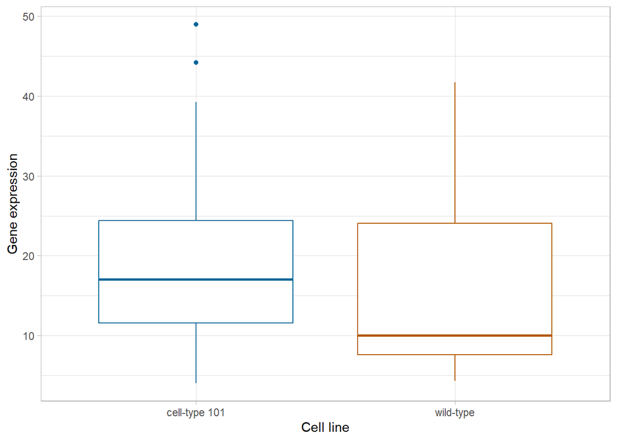

Figure 1: A boxplot of gene expression for each cell line (wild-type and cell-type 101).

A boxplot of gene expression, grouped by cell line, is shown in Figure 1. From this boxplot, it can be seen that there does not appear to be a significant difference between gene expression for wild-type and gene expression for cell-type 101. This suggests that cell line may not be a predictor of gene expression, or at least, not on its own.

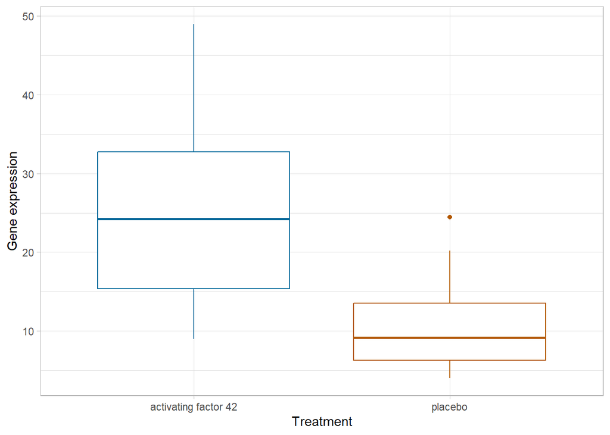

Figure 2: A boxplot of gene expression for each treatment (placebo and activating factor 42).

Figure 2 shows a boxplot of gene expression for each treatment type (placebo or activating factor 42). From this boxplot, it can be seen that there does appear to be a difference between gene expression for placebo and gene expression for activating factor 42. This suggests that treatment is a predictor of gene expression.

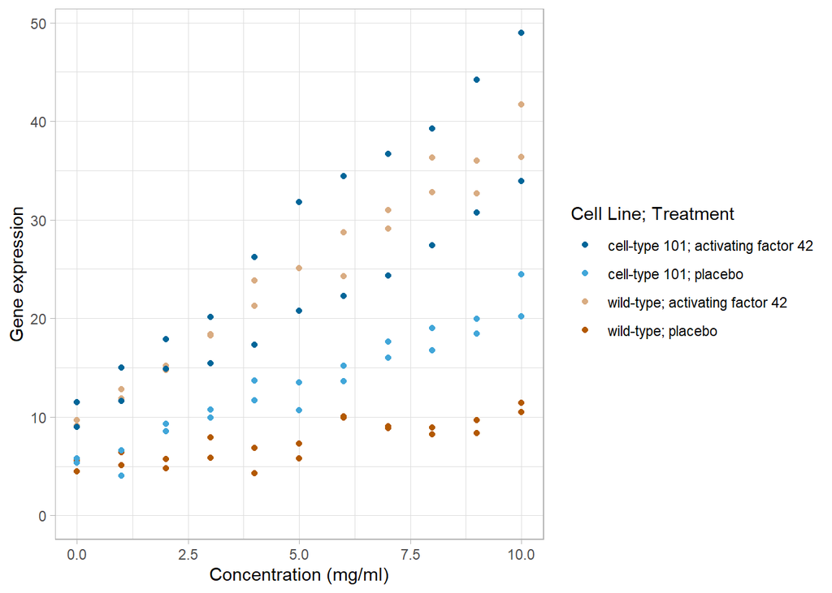

Figure 3: A plot of gene expression as a function of concentration, coloured by cell line (wild-type or cell-type 101) and treatment (placebo or activating factor 42).

The data is plotted in Figure 3, with gene expression on the y axis and concentration on the x axis, with the data points coloured by cell line and treatment. From this plot, it can be seen that there does appear to be a relationship between concentration and gene expression, which suggests that concentration is a predictor of gene expression. From Figure 3, it can be seen that there appear to be differences between the pairs (cell-type 101, placebo) and (wild-type, placebo) and the other two pairs of cell line and treatment. However, there does not appear to be a difference between (cell-type 101, activating factor 42) and (wild-type, activating factor 42). This suggests that for the placebo treatment, cell line has an impact on gene expression, but for the activating factor, cell line may not have an impact on gene expression. Thus, cell line may be a predictor for gene expression.

A linear model can be fit using the `step` function to select the best model based on AIC, where the full scope is gene expression as a function of concentration, treatment, and cell line, with interaction terms between all three predictors. Using AIC, the function selects the full model as the best model.

[output not shown]

However, this does not consider the impact of gene line. A model can be fitted for gene expression as a function of concentration, with gene line as a random effect. The residuals plot for this model is shown in Figure 4. From this figure, it can be seen that there is still variance not explained by concentration alone, so this model will not be considered further.

```
Linear mixed model fit by REML. t-tests use Satterthwaite's method [
lmerModLmerTest]
Formula: GE ~ concentration + (1 | GL)
   Data: data_long

REML criterion at convergence: 506.2

Scaled residuals:
     Min       1Q   Median       3Q      Max
-2.03686 -0.51171 -0.05062  0.55788  2.46633

Random effects:
 Groups   Name        Variance Std.Dev.
 GL       (Intercept) 68.48    8.275
 Residual             14.27    3.777
Number of obs: 87, groups:  GL, 8

Fixed effects:
              Estimate Std. Error      df t value Pr(>|t|)
(Intercept)     7.2948     3.0215  7.6657   2.414   0.0435 *
concentration   2.0461     0.1273 78.0015  16.069   <2e-16 ***
---
Signif. codes:  0 '***' 0.001 '**' 0.01 '*' 0.05 '.' 0.1 ' ' 1

Correlation of Fixed Effects:
            (Intr)
concentratn -0.211
```

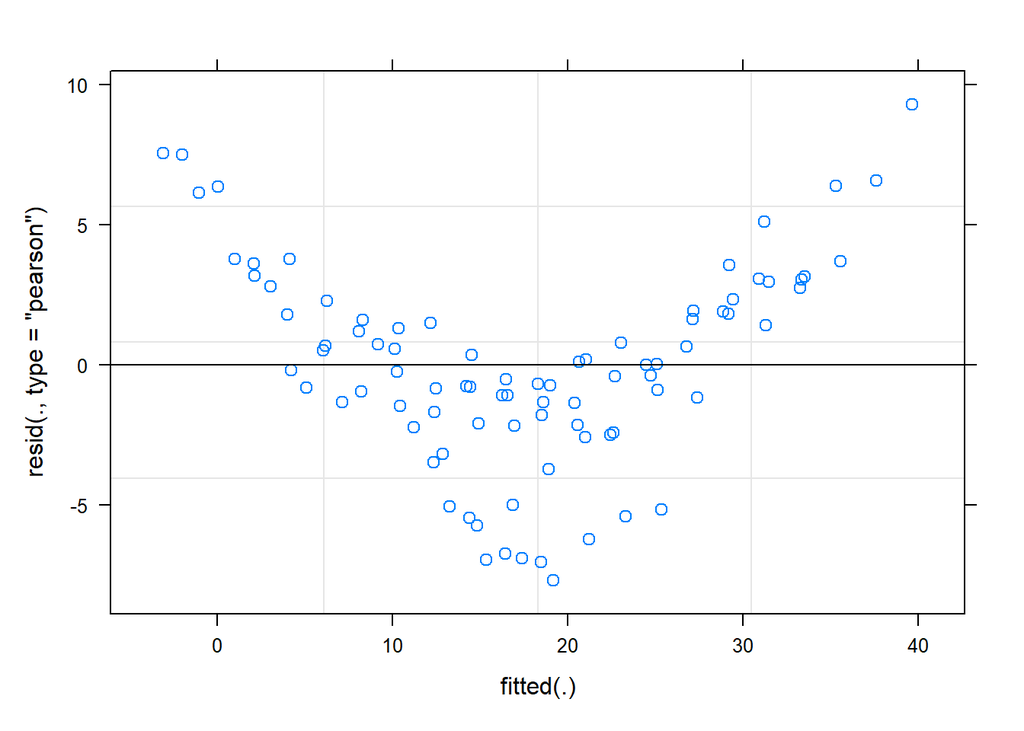

Figure 4: The residuals plot for the model of gene expression as a function of concentration, with gene line as a random effect.

The next model considered fits gene expression as a function of concentration and treatment (with interaction terms), as well as gene line as a random effect. The residuals plot for this model is shown in Figure 5.

```
Linear mixed model fit by REML. t-tests use Satterthwaite's method [
lmerModLmerTest]
Formula: GE ~ concentration * treatment + (1 | GL)
   Data: data_long

REML criterion at convergence: 396.5

Scaled residuals:
     Min       1Q   Median       3Q      Max
-1.84951 -0.73934 -0.04455  0.72880  2.38181

Random effects:
 Groups   Name        Variance Std.Dev.
 GL       (Intercept) 12.609   3.551
 Residual              4.255   2.063
Number of obs: 87, groups:  GL, 8

Fixed effects:
                               Estimate Std. Error       df t value Pr(>|t|)
(Intercept)                     9.73729    1.86897  6.93144   5.210  0.00128
concentration                   2.99068    0.09834 77.00344  30.413  < 2e-16
treatmentplacebo               -4.88126    2.64267  6.92670  -1.847  0.10767
concentration:treatmentplacebo -1.88920    0.13907 77.00344 -13.585  < 2e-16

(Intercept)                    **
concentration                  ***
treatmentplacebo
concentration:treatmentplacebo ***
---
Signif. codes:  0 '***' 0.001 '**' 0.01 '*' 0.05 '.' 0.1 ' ' 1

Correlation of Fixed Effects:
            (Intr) cncntr trtmnt
concentratn -0.263
tretmntplcb -0.707  0.186
cncntrtn:tr  0.186 -0.707 -0.263
```

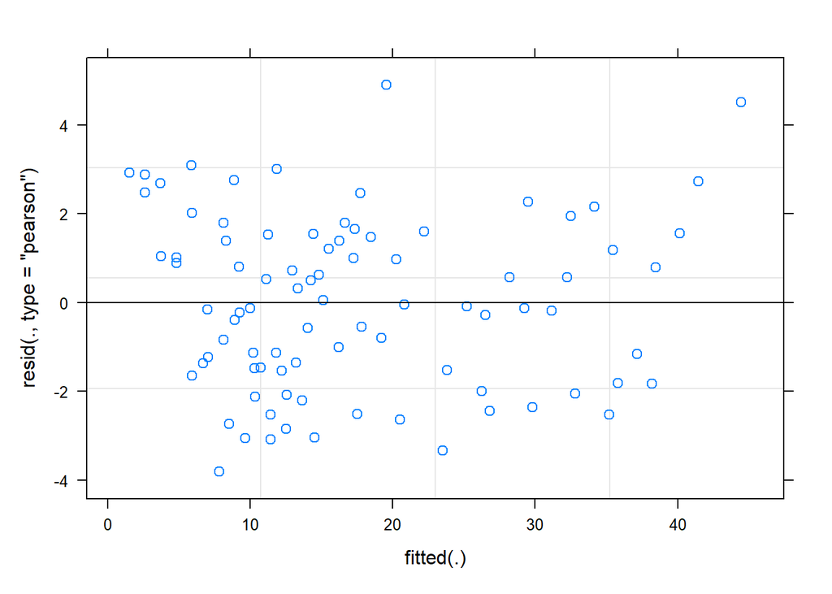

Figure 5: The residuals plot for the model of gene expression as a function of concentration and treatment (with interaction terms), with gene line as a random effect.

Two models are fitted that include cell line as a predictor. One with interaction terms between concentration and treatment only, and one with interaction terms between concentration, treatment and cell line. The residuals plots for these models are shown in Figure 6 and Figure 7, respectively.

```
Linear mixed model fit by REML. t-tests use Satterthwaite's method [
lmerModLmerTest]
Formula: GE ~ concentration * treatment + CL + (1 | GL)
   Data: data_long

REML criterion at convergence: 391

Scaled residuals:
     Min       1Q   Median       3Q      Max
-1.87305 -0.77007 -0.03212  0.71414  2.36286

Random effects:
 Groups   Name        Variance Std.Dev.
 GL       (Intercept) 10.729   3.275
 Residual              4.255   2.063
Number of obs: 87, groups:  GL, 8

Fixed effects:
                               Estimate Std. Error       df t value Pr(>|t|)
(Intercept)                    11.40960    2.10015  5.59703   5.433  0.00201
concentration                   2.99068    0.09834 77.00431  30.413  < 2e-16
treatmentplacebo               -4.88000    2.45837  5.90950  -1.985  0.09509
CLwild-type                    -3.34716    2.35799  5.00431  -1.419  0.21493
concentration:treatmentplacebo -1.88920    0.13907 77.00431 -13.585  < 2e-16

(Intercept)                    **
concentration                  ***
treatmentplacebo               .
CLwild-type
concentration:treatmentplacebo ***
---
Signif. codes:  0 '***' 0.001 '**' 0.01 '*' 0.05 '.' 0.1 ' ' 1

Correlation of Fixed Effects:
            (Intr) cncntr trtmnt CLwld-
concentratn -0.234
tretmntplcb -0.585  0.200
CLwild-type -0.561  0.000  0.000
cncntrtn:tr  0.166 -0.707 -0.283  0.000
```

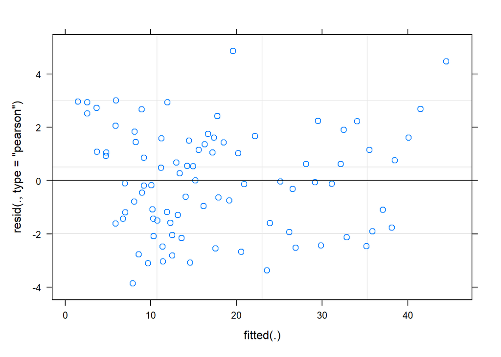

Figure 6: The residuals plot for the model of gene expression as a function of concentration and treatment (with interaction terms) and cell line (without any interaction terms), with gene line as a random effect.

```
Linear mixed model fit by REML. t-tests use Satterthwaite's method [
lmerModLmerTest]
Formula: GE ~ concentration * treatment * CL + (1 | GL)
   Data: data_long

REML criterion at convergence: 349.1

Scaled residuals:
     Min       1Q   Median       3Q      Max
-2.02535 -0.53265 -0.04358  0.58637  2.57581

Random effects:
 Groups   Name        Variance Std.Dev.
 GL       (Intercept) 10.828   3.291
 Residual              2.608   1.615
Number of obs: 87, groups:  GL, 8

Fixed effects:
                                           Estimate Std. Error       df t value
(Intercept)                                 9.91750    2.41428  4.43886   4.108
concentration                               3.05141    0.10887 75.00175  28.027
treatmentplacebo                           -4.92159    3.41431  4.43886  -1.441
CLwild-type                                -0.36156    3.41518  4.44335  -0.106
concentration:treatmentplacebo             -1.40550    0.15397 75.00175  -9.128
concentration:CLwild-type                  -0.12145    0.15397 75.00175  -0.789
treatmentplacebo:CLwild-type                0.08179    4.82918  4.44111   0.017
concentration:treatmentplacebo:CLwild-type -0.96741    0.21775 75.00175  -4.443
                                           Pr(>|t|)
(Intercept)                                  0.0119 *
concentration                               < 2e-16 ***
treatmentplacebo                             0.2161
CLwild-type                                  0.9203
concentration:treatmentplacebo             8.48e-14 ***
concentration:CLwild-type                    0.4327
treatmentplacebo:CLwild-type                 0.9872
concentration:treatmentplacebo:CLwild-type 3.01e-05 ***
---
Signif. codes:  0 '***' 0.001 '**' 0.01 '*' 0.05 '.' 0.1 ' ' 1

Correlation of Fixed Effects:
            (Intr) cncntr trtmnt CLwld- cncnt: cn:CL- tr:CL-
concentratn -0.225
tretmntplcb -0.707  0.159
CLwild-type -0.707  0.159  0.500
cncntrtn:tr  0.159 -0.707 -0.225 -0.113
cncntrt:CL-  0.159 -0.707 -0.113 -0.225  0.500
trtmntp:CL-  0.500 -0.113 -0.707 -0.707  0.159  0.159
cncntr::CL- -0.113  0.500  0.159  0.159 -0.707 -0.707 -0.225
```

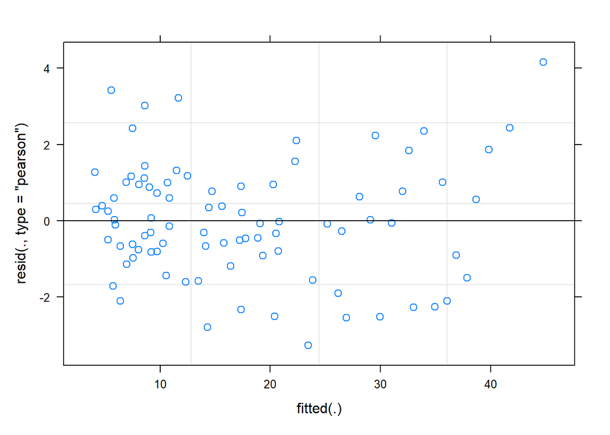

Figure 7: The residuals plot for the model of gene expression as a function of concentration, treatment and cell line (with interaction terms between all three predictors), with gene line as a random effect.

Table 1: The estimates and p-values for these estimates for the mixed effects model with concentration, treatment and cell line predictors, and an interaction term between concentration and treatment, as well as a gene line random effects.

| Predictors | GE Estimates | GE CI | GE p |
| --- | --- | --- | --- |
| (Intercept) | 11.41 | 7.23 – 15.59 | <0.001 |
| concentration | 2.99 | 2.79 – 3.19 | <0.001 |
| treatment [placebo] | -4.88 | -9.77 – 0.01 | 0.051 |
| CL [wild-type] | -3.35 | -8.04 – 1.35 | 0.160 |
| concentration * treatment[placebo] | -1.89 | -2.17 – -1.61 | <0.001 |
| Random Effects |  |  |  |
| s2 | 4.25 |  |  |
| t00GL | 10.73 |  |  |
| ICC | 0.72 |  |  |
| N GL | 8 |  |  |
| Observations | 87 |  |  |
| Marginal $R^2$ / Conditional $R^2$ | 0.877 / 0.965 |  |  |

Table 1 shows the estimates and p-values for these estimates for the mixed effects model with concentration and treatment (with the interaction term) and cell line (without interactions with this predictor), as well as the gene line random effects. From this table, it can be seen that the cell line predictor is not statistically significant, so this term should be removed from the model. Removing this term results in the mixed effects models with concentration and treatment predictors (with the interaction term) and the gene line random effects. The estimates for this model are shown in Table 2, along with the p-values for these estimates.

Table 2: The estimates and p-values for these estimates for the mixed effects model with concentration and treatment predictors, and an interaction term, as well as a gene line random effects.

| Predictors | GE Estimates | GE CI | GE p |
| --- | --- | --- | --- |
| (Intercept) | 9.74 | 6.02 – 13.46 | <0.001 |
| concentration | 2.99 | 2.80 – 3.19 | <0.001 |
| treatment [placebo] | -4.88 | -10.14 – 0.38 | 0.068 |
| concentration * treatment[placebo] | -1.89 | -2.17 – -1.61 | <0.001 |
| Random Effects |  |  |  |
| s2 | 4.25 |  |  |
| t00GL | 12.61 |  |  |
| ICC | 0.75 |  |  |
| N GL | 8 |  |  |
| Observations | 87 |  |  |
| Marginal $R^2$ / Conditional $R^2$ | 0.860 / 0.965 |  |  |

Table 3: The estimates and p-values for these estimates for the mixed effects model with concentration, treatment and cell line predictors, and interaction terms between all of the predictors, as well as a gene line random effects.

| Predictors | GE Estimates | GE CI | GE p |
| --- | --- | --- | --- |
| (Intercept) | 9.92 | 5.11 – 14.72 | <0.001 |
| concentration | 3.05 | 2.83 – 3.27 | <0.001 |
| treatment [placebo] | -4.92 | -11.72 – 1.88 | 0.154 |
| CL [wild-type] | -0.36 | -7.16 – 6.44 | 0.916 |
| concentration * treatment[placebo] | -1.41 | -1.71 – -1.10 | <0.001 |
| concentration * CL[wild-type] | -0.12 | -0.43 – 0.19 | 0.433 |
| treatment [placebo] * CL[wild-type] | 0.08 | -9.53 – 9.70 | 0.987 |
| (concentration *treatment [placebo]) * CL[wild-type] | -0.97 | -1.40 – -0.53 | <0.001 |
| Random Effects |  |  |  |
| s2 | 2.61 |  |  |
| t00GL | 10.83 |  |  |
| ICC | 0.81 |  |  |
| N GL | 8 |  |  |
| Observations | 87 |  |  |
| Marginal $R^2$ / Conditional $R^2$ | 0.891 / 0.979 |  |  |

Table 3 shows the estimates and p-values for the model with concentration, treatment and cell line as predictors, along with interaction terms between all predictors, and gene line random effects. From this table, it can be seen that the interaction term between concentration, treatment and cell line is statistically significant, so this term should be kept. Because this term should be kept, then all of the other fixed effect terms should also be kept.

Table 4: The estimates and p-values for these estimates for the fixed effects model.

| Predictors | GE Estimates | GE CI | GE p |
| --- | --- | --- | --- |
| (Intercept) | 9.92 | 7.59 – 12.25 | <0.001 |
| concentration | 3.05 | 2.66 – 3.45 | <0.001 |
| treatment [placebo] | -4.92 | -8.22 – -1.62 | 0.004 |
| CL [wild-type] | -0.31 | -3.62 – 2.99 | 0.850 |
| concentration * treatment[placebo] | -1.41 | -1.96 – -0.85 | <0.001 |
| concentration * CL[wild-type] | -0.12 | -0.68 – 0.44 | 0.666 |
| treatment [placebo] * CL[wild-type] | 0.04 | -4.64 – 4.71 | 0.988 |
| (concentration *treatment [placebo]) * CL[wild-type] | -0.97 | -1.76 – -0.18 | 0.017 |
| Observations | 87 |  |  |
| $R^2$ / $R^2$ adjusted | 0.933 / 0.927 |  |  |

The estimates for two remaining mixed effects models being studied are shown in Table 2 and Table 3, whilst the fixed effects model is shown in Table 4.

|  | npar | logLik | AIC | LRT | Df | Pr(>Chisq) |
| --- | --- | --- | --- | --- | --- | --- |
| <none> | 6 | -198.2331 | 408.4662 |  |  |  |
| (1 \| GL) | 5 | -237.8918 | 485.7837 | 79.31749 | 1 | 5.288934e-19 |

|  | npar | logLik | AIC | LRT | Df | Pr(>Chisq) |
| --- | --- | --- | --- | --- | --- | --- |
| <none> | 10 | -174.5644 | 369.1289 |  |  |  |
| (1 \| GL) | 9 | -214.1471 | 446.2942 | 79.16527 | 1 | 5.712558e-19 |

Table 5 and Table 6 show the results of applying the function `ranova` to the two mixed effects models considered. From these tables, it can be seen that the random effects are significant in both models. Thus, these random effect terms should not be removed.

Table 7: The AIC, R^{2} values and root mean squared errors for each of the three fitted models.

| Name | AIC | R2 | R2_conditional | RMSE |
| --- | --- | --- | --- | --- |
| lm_step | 443.9494 | 0.9327916 |  | 2.798396 |
| m2 | 408.8027 |  | 0.9647610 | 1.942813 |
| m4 | 372.5428 |  | 0.9788391 | 1.500209 |

# Discussion

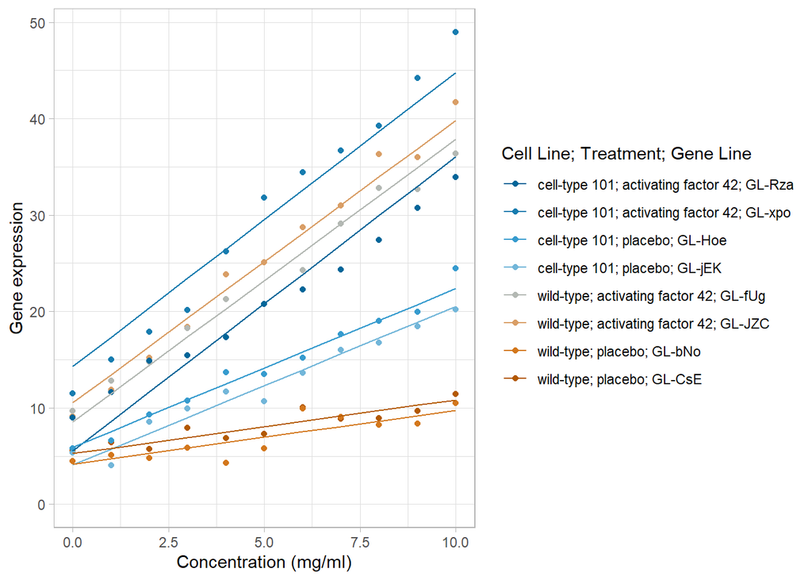

Figure 8: A plot of gene expression as a function of concentration, coloured by gene line (with cell line and treatment also indicated), and with the fitted model indicated by the lines.

The chosen model is the mixed effects model with concentration, treatment and cell line as predictors, along with all interaction terms between the three predictors, and gene line as a random effect. This model is shown as the lines in Figure 8, where each line is the fitted model for a different gene line. This figure shows how the gene lines with the placebo treatment (in darker brown and lighter blue) have a flatter slope than the gene lines with the activating factor 42 treatment (in lighter brown, grey and darker blue). The slope of the fitted model for the wild-type cell lines with the placebo treatments (in darker brown) is also flatter than the slope of the fitted model for the cell-type 101 cell lines with the placebo treatments (in lighter blue).

The coefficients of the fitted model are shown in Table 8, and the random intercepts are shown in Table 9. The intercept for each gene line is found as the overall intercept (in Table 8) plus the gene line specific intercept in Table 9.

|  | value |
| --- | --- |
| (Intercept) | 9.9175000 |
| concentration | 3.0514091 |
| treatmentplacebo | -4.9215909 |
| CLwild-type | -0.3615634 |
| concentration:treatmentplacebo | -1.4055000 |
| concentration:CLwild-type | -0.1214545 |
| treatmentplacebo:CLwild-type | 0.0817907 |
| concentration:treatmentplacebo:CLwild-type | -0.9674091 |

|  | value |
| --- | --- |
| GL-bNo | -0.5448884 |
| GL-CsE | 0.5448884 |
| GL-fUg | -0.9801050 |
| GL-Hoe | 0.9171917 |
| GL-jEK | -0.9171917 |
| GL-JZC | 0.9801050 |
| GL-Rza | -4.3688926 |
| GL-xpo | 4.3688926 |

From these tables, it can be seen that as growth factor concentration increases, so does gene expression. It can also be seen that the placebo treatment has a smaller intercept and flatter slope than the activating factor 42 treatment does. Similarly, the wild-type cell line has a lower intercept and flatter slope than the cell-type 101 cell line does. Thus, gene expression is higher for higher concentrations of the growth factor, the activating factor 42 treatment and cell-type 101 cell line. Conversely, lower concentrations of the growth factor, the placebo treatment and wild-type cell line results in lower gene expression.

# Appendix: Code

```r
pacman::p_load(tidyverse, readr, lme4, knitr, performance, sjPlot, lmerTest, sjtable2df)
options(knitr.kable.NA = "")
theme_set(theme_light())
data <- read_csv("data/2023-03-01_gene-data.csv")
data_long <- data %>%
  mutate(CL = `cell line`,
         treat = treatment) %>%
  unite(`cell line`, `treat`, sep = "; ", col = "grouping") %>%
  pivot_longer(cols = 4:14, names_to = "concentration", values_to = "GE") %>%
  filter(GE >= 0) %>%
  mutate(concentration = as.integer(concentration),
         GL = as.factor(sheet_names),
         CL = as.factor(CL),
         treatment = as.factor(treatment),
         grouping = as.factor(grouping))
data_long %>%
  ggplot(aes(x = CL, y = GE, col = CL)) +
  geom_boxplot() +
  theme(legend.position = 'none') +
  harrypotter::scale_color_hp_d("Ravenclaw") +
  labs(x = "Cell line",
       y = "Gene expression")
data_long %>%
  ggplot(aes(x = treatment, y = GE, col = treatment)) +
  geom_boxplot() +
  theme(legend.position = 'none') +
  harrypotter::scale_color_hp_d("Ravenclaw") +
  labs(x = "Treatment",
       y = "Gene expression")
data_long %>%
  ggplot(aes(x = concentration, y = GE, color = grouping)) +
  geom_point() +
  ylim(0, NA) +
  harrypotter::scale_color_hp_d("Ravenclaw") +
  labs(x = "Concentration (mg/ml)",
       y = "Gene expression",
       color = "Cell Line; Treatment")
m1 <- lmer(GE ~ concentration + (1|GL), data = data_long, na.action = na.omit)
summary(m1)
plot(m1)
m2 <- lmer(GE ~ concentration*treatment + (1|GL), data = data_long, na.action = na.omit)
summary(m2)
plot(m2)
m3 <- lmer(GE ~ concentration*treatment + CL + (1|GL), data = data_long, na.action = na.omit)
summary(m3)
plot(m3)
m4 <- lmer(GE ~ concentration*treatment*CL + (1|GL), data = data_long, na.action = na.omit)
summary(m4)
plot(m4)
# tab_model(m3)
mtab2df(tab_model(m3), n_models=1, output = "kable")
# tab_model(m2)
mtab2df(tab_model(m2), n_models=1, output = "kable")
# tab_model(m4)
mtab2df(tab_model(m4), n_models=1, output = "kable")
lm_step <- lm(GE ~ concentration*treatment*CL, data = data_long)
# tab_model(lm_step, m2, m4)
mtab2df(tab_model(lm_step), n_models=1, output = "kable")
ranova(m2) %>%
  kable(digits = c(0,4,4,5,4,25))
ranova(m4) %>%
  kable(digits = c(0,4,4,5,4,25))
compare_performance(lm_step, m2, m4) %>%
  select(c("Name", "AIC", "R2", "R2_conditional", "RMSE")) %>%
  kable(digits = c(0,4,7,7,6))
data_long %>%
  mutate(group = grouping,
         geneline = GL) %>%
  unite(group, geneline, sep = "; ", col = "grouping2") %>%
  ggplot(aes(x = concentration, y = GE, color = grouping2)) +
  geom_point() +
  geom_line(aes(y = predict(m4))) +
  ylim(0, NA) +
  # scale_color_manual(values=c("#006699", "#006699", "#98C2D9", "#98C2D9", "#D9AC82", "#D9AC82", "#B35900", "#B35900")) +
  harrypotter::scale_color_hp_d("Ravenclaw") +
  labs(x = "Concentration (mg/ml)",
       y = "Gene expression",
       color = "Cell Line; Treatment; Gene Line")
fixef(m4) %>%
  data.frame() %>%
  rename(value = ".") %>%
  kable()
random_effects <- ranef(m4)$GL
random_effects %>%
  rename(value = `(Intercept)`) %>%
  kable()
```

## References

Bates, Douglas, Martin Mächler, Ben Bolker, and Steve Walker. 2015. “Fitting Linear Mixed-Effects Models Using lme4.” *Journal of Statistical Software* 67 (1): 1–48. https://doi.org/10.18637/jss.v067.i01.

Kassambara, Alboukadel. 2023a. *ggpubr: ’ggplot2’ Based Publication Ready Plots*. https://CRAN.R-project.org/package=ggpubr.

———. 2023b. *rstatix: Pipe-Friendly Framework for Basic Statistical Tests*. https://CRAN.R-project.org/package=rstatix.

Kuznetsova, Alexandra, Per B. Brockhoff, and Rune H. B. Christensen. 2017. “lmerTest Package: Tests in Linear Mixed Effects Models.” *Journal of Statistical Software* 82 (13): 1–26. https://doi.org/10.18637/jss.v082.i13.

Lüdecke, Daniel. 2023. *sjPlot: Data Visualization for Statistics in Social Science*. https://CRAN.R-project.org/package=sjPlot.

Lüdecke, Daniel, Mattan S. Ben-Shachar, Indrajeet Patil, Philip Waggoner, and Dominique Makowski. 2021. “performance: An R Package for Assessment, Comparison and Testing of Statistical Models.” *Journal of Open Source Software* 6 (60): 3139. https://doi.org/10.21105/joss.03139.

Pedersen, Thomas Lin. 2022. *patchwork: The Composer of Plots*. https://CRAN.R-project.org/package=patchwork.

Qiu, Yixuan, and authors/contributors of the included software. 2022. *showtext: Using Fonts More Easily in r Graphs*. https://CRAN.R-project.org/package=showtext.

R Core Team. 2022. *R: A Language and Environment for Statistical Computing*. Vienna, Austria: R Foundation for Statistical Computing. https://www.R-project.org/.

Slowikowski, Kamil. 2023. *ggrepel: Automatically Position Non-Overlapping Text Labels with ’ggplot2’*. https://CRAN.R-project.org/package=ggrepel.

Wickham, Hadley, Mara Averick, Jennifer Bryan, Winston Chang, Lucy D’Agostino McGowan, Romain François, Garrett Grolemund, et al. 2019. “Welcome to the tidyverse.” *Journal of Open Source Software* 4 (43): 1686. https://doi.org/10.21105/joss.01686.

Wickham, Hadley, Jim Hester, and Jennifer Bryan. 2023. *readr: Read Rectangular Text Data*. https://CRAN.R-project.org/package=readr.

Xie, Yihui. 2023. *knitr: A General-Purpose Package for Dynamic Report Generation in r*. https://yihui.org/knitr/.